# Before and After Black Rock City

## Volunteerism and Skills Inspired

## Volunteerism

### Evaluation of Whether Black Rock City Visit Inspired Volunteerism or Involvement in Local Community

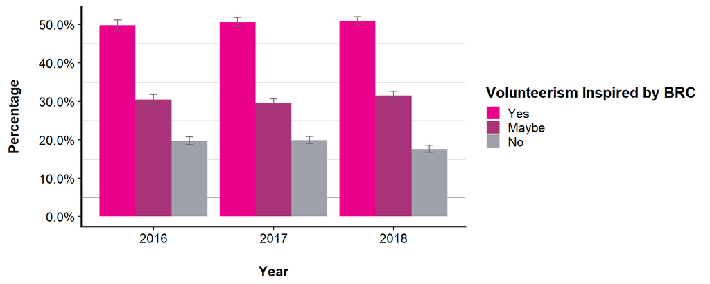

Error bars indicate the upper and lower bounds of the 95% confidence intervals.

|  | 2016 Percent | 2016 MoE +/- % |  | 2017 Percent | 2017 MoE +/- % |  | 2018 Percent | 2018 MoE +/- % |
| --- | --- | --- | --- | --- | --- | --- | --- | --- |
| Yes | 49.8 | 1.4 |  | 50.6 | 1.2 |  | 50.9 | 1.2 |
| Maybe | 30.5 | 1.2 |  | 29.5 | 1.2 |  | 31.5 | 1.2 |
| No | 19.7 | 1.0 |  | 19.9 | 1.0 |  | 17.6 | 1.0 |

## Volunteerism

### Volunteerism Over the Past Year*

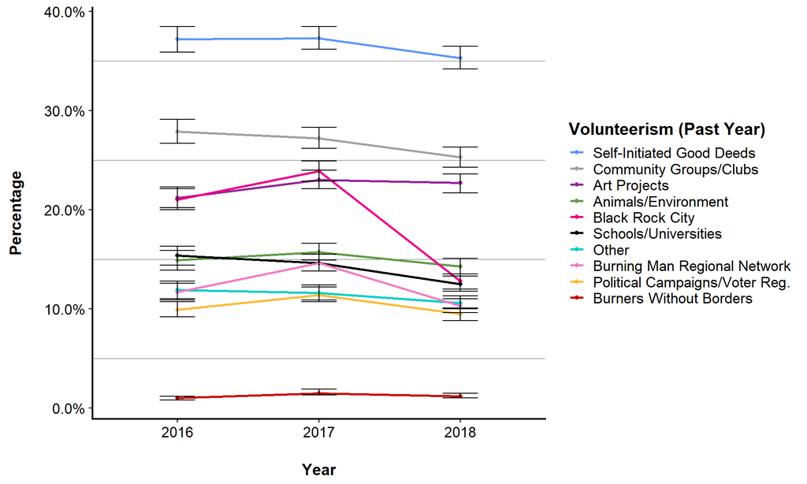

Error bars indicate the upper and lower bounds of the 95% confidence intervals.

* Participants selected all option(s) that applied.

|  | 2016 Percent | 2016 MoE +/- % |  | 2017 Percent | 2017 MoE +/- % |  | 2018 Percent | 2018 MoE +/- % |
| --- | --- | --- | --- | --- | --- | --- | --- | --- |
| Self-Initiated Good Deeds | 37.2 | 1.4 |  | 37.3 | 1.2 |  | 35.3 | 1.2 |
| Community Groups/Clubs | 27.9 | 1.2 |  | 27.2 | 1.0 |  | 25.3 | 1.0 |
| Art Projects | 21.2 | 1.0 |  | 23.0 | 1.0 |  | 22.7 | 1.0 |
| Animals/Environment | 14.9 | 1.0 |  | 15.7 | 0.8 |  | 14.3 | 0.8 |
| Black Rock City | 21.0 | 1.0 |  | 23.9 | 1.0 |  | 12.8 | 0.8 |
| Schools/Universities | 15.4 | 1.0 |  | 14.6 | 0.8 |  | 12.5 | 0.8 |
| Other | 11.9 | 0.8 |  | 11.6 | 0.8 |  | 10.6 | 0.6 |
| Burning Man Regional Network | 11.7 | 0.8 |  | 14.6 | 0.8 |  | 10.3 | 0.6 |
| Political Campaigns/Voter Reg. | 9.9 | 0.8 |  | 11.4 | 0.8 |  | 9.5 | 0.6 |
| Burners Without Borders | 1.0 | 0.2 |  | 1.5 | 0.4 |  | 1.2 | 0.2 |

## Volunteerism

In the 2018 online survey participants were also asked the question, "Approximately how many hours per month did you spend on these volunteer efforts in the last year?"  
Participants indicated an average of 18.4 (+/- 1.1) hours volunteering per month.

## Skills Inspired

### Evaluation of Whether Black Rock City Visit Inspired Skill Acquisition or Practice

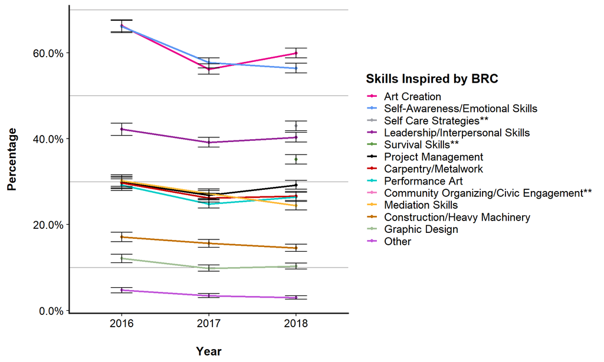

Error bars indicate the upper and lower bounds of the 95% confidence intervals.

* Participants selected all option(s) that applied.  
** "Community Organizing/Civic Engagement," "Self Care Strategies," and "Survival Skills" were first added as options to the 2018 online survey.

|  | 2016 Percent | 2016 MoE +/- % |  | 2017 Percent | 2017 MoE +/- % |  | 2018 Percent | 2018 MoE +/- % |
| --- | --- | --- | --- | --- | --- | --- | --- | --- |
| Art Creation | 66.3 | 1.4 |  | 56.2 | 1.2 |  | 59.9 | 1.2 |
| Self-Awareness/Emotional Skills | 66.1 | 1.4 |  | 57.7 | 1.2 |  | 56.4 | 1.2 |
| Self Care Strategies** | NA | NA |  | NA | NA |  | 43.0 | 1.2 |
| Leadership/Interpersonal Skills | 42.2 | 1.4 |  | 39.1 | 1.2 |  | 40.3 | 1.2 |
| Survival Skills** | NA | NA |  | NA | NA |  | 35.2 | 1.2 |
| Project Management | 29.8 | 1.4 |  | 26.8 | 1.0 |  | 29.2 | 1.0 |
| Carpentry/Metalwork | 29.7 | 1.4 |  | 26.2 | 1.0 |  | 26.6 | 1.0 |
| Performance Art | 29.2 | 1.4 |  | 24.8 | 1.0 |  | 26.4 | 1.0 |
| Community Organizing/Civic Engagement** | NA | NA |  | NA | NA |  | 24.4 | 1.0 |
| Mediation Skills | 30.2 | 1.4 |  | 27.2 | 1.2 |  | 24.4 | 1.0 |
| Construction/Heavy Machinery | 17.1 | 1.2 |  | 15.6 | 0.8 |  | 14.5 | 0.8 |
| Graphic Design | 12.1 | 1.0 |  | 9.8 | 0.8 |  | 10.3 | 0.8 |
| Other | 4.7 | 0.6 |  | 3.4 | 0.4 |  | 3.0 | 0.4 |

## Skills Inspired

### Impact of Skill(s) Outside of Black Rock City*

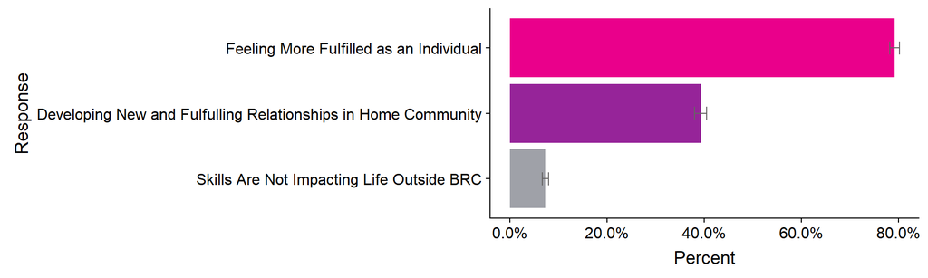

Error bars indicate the upper and lower bounds of the 95% confidence intervals.

* This question was first introduced in the 2018 online survey. Data presented in the plot above and table below are for participants who indicated being inspired to learn or practice skill(s) following their visit to Black Rock City. Participants selected all option(s) that applied.

|  | 2018 Percent | 2018 MoE +/- % |
| --- | --- | --- |
| Feeling More Fulfilled as an Individual | 79.2 | 1.0 |
| Developing New and Fulfulling Relationships in Home Community | 39.3 | 1.2 |
| Skills Are Not Impacting Life Outside BRC | 7.3 | 0.6 |

## Skills Inspired

### Evaluation of Usefulness* of Skills Learned or Practiced After Black Rock City Visit

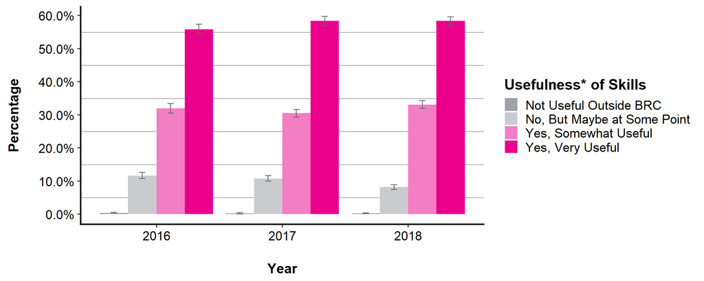

Error bars indicate the upper and lower bounds of the 95% confidence intervals.

* This question in the online survey specifically asked if any skill(s) a participant was inspired to learn or practice after visiting Black Rock City have proved useful "in the default world."

|  | 2016 Percent | 2016 MoE +/- % |  | 2017 Percent | 2017 MoE +/- % |  | 2018 Percent | 2018 MoE +/- % |
| --- | --- | --- | --- | --- | --- | --- | --- | --- |
| Not Useful Outside BRC | 0.4 | 0.2 |  | 0.3 | 0.2 |  | 0.3 | 0.2 |
| No, But Maybe at Some Point | 11.7 | 1.0 |  | 10.8 | 0.8 |  | 8.2 | 0.8 |
| Yes, Somewhat Useful | 32.0 | 1.4 |  | 30.5 | 1.2 |  | 33.1 | 1.2 |
| Yes, Very Useful | 55.9 | 1.4 |  | 58.4 | 1.4 |  | 58.4 | 1.2 |

## Skills Inspired

### Application of Skill(s) Outside of Black Rock City*

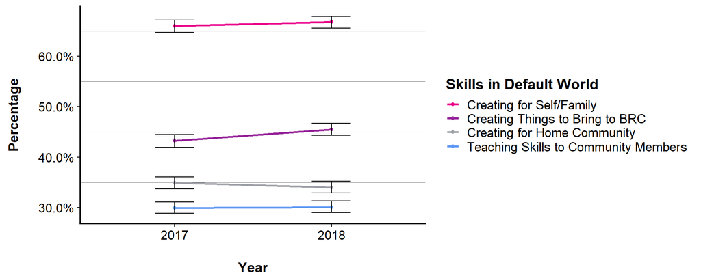

Error bars indicate the upper and lower bounds of the 95% confidence intervals.

* Data presented here are for participants who indicated being inspired to learn or practice skill(s) following their visit to Black Rock City. Participants selected all option(s) that applied.

|  | 2017 Percent | 2017 MoE +/- % |  | 2018 Percent | 2018 MoE +/- % |
| --- | --- | --- | --- | --- | --- |
| Creating for Self/Family | 66.0 | 1.2 |  | 66.8 | 1.2 |
| Creating Things to Bring to BRC | 43.2 | 1.2 |  | 45.5 | 1.2 |
| Creating for Home Community | 34.9 | 1.2 |  | 34.0 | 1.2 |
| Teaching Skills to Community Members | 29.9 | 1.2 |  | 30.1 | 1.2 |

**Next:** Before and After Black Rock City: Relationship with Others and Relationship with Nature